## iterative Random Forests (iRF)

The R package *iRF* implements iterative Random Forests, a method for iteratively growing ensemble of weighted decision trees, and detecting high-order feature interactions by analyzing feature usage on decision paths. This version uses source codes from the R package `randomForest` by Andy Liaw and Matthew Weiner, the original Fortran codes by Leo Breiman and Adele Cutler, and source codes from the R package `FSInteract` by Hyun Jik Kim and Rajen D. Shah.

iRF can be loaded using the `library` command:

```r
library(iRF)
```

`iRF` adds two new features to Breiman’s original Random Forest workflow:

## A. Weighted random forest

Unlike Breiman’s original random forest, which uses uniform random sampling to select variables during each node split, the ‘randomForest’ function in ‘iRF’ allows non-uniform sampling using a given vector of nonnegative weights (e.g., feature importances from a previous model fit). In particular, given a vector of weights $\mathbf{w} = (w_1, \ldots, w_p)$, the `mtry` variables are selected so that $P($variable $j$ is selected) = w_j/_{j=1}^p w_j$, for $j = 1, \ldots, p$. In addition, one can supply a subset of features which will always be selected during split selection, in addition to the features (as if setting $w_j = \infty$ for a subset of features).

Based on this weighting scheme, we can iteratively grow weighted random forests, where Gini importances from the previous random forest fit are used as weights in the current iteration.

```r
# set seed for random number generation
set.seed(53)
```

### Binary Classification:

We simulate some data for a binary classification exercise. Out of $250$ features, only four $\{1, 2, 5, 7\}$ are important.

```r
  # simulate data for classification
  n <- 200
  p <- 250
  X <- matrix(rnorm(n * p), nrow=n)

  Y <- (X[,1] > 0.35 & X[,2] > 0.35) | (X[,5] > 0.35 & X[,7] > 0.35)
  Y <- as.factor(as.numeric(Y > 0))

  train.id <- 1:(n / 2)
  test.id <- setdiff(1:n, train.id)
```

Next, we iteratively grow weighted random forests and use feature importances from last iteration as weights.

```r
sel.prob <- rep(1/p, p)

# iteratively grow RF, use Gini importance of features as weights
rf = list()
for (iter in 1:4){
  rf[[iter]] <- randomForest(x=X[train.id,], y=Y[train.id],
                             xtest=X[test.id,], ytest=Y[test.id],
                             mtry.select.prob=sel.prob)

  # update selection probabilities for next iteration
  sel.prob <- rf[[iter]]$importance
}
```

### ROC curve

We can measure performance of different iterations of RF on the test set:

```r
library(AUC)
```

```r
plot(0:1, 0:1, type='l', lty = 2, xlab = 'FPR', ylab = 'TPR', main='ROC Curve')
for (iter in 1:4){
  # performance on test set
  cat(paste('iter = ', iter, ':: '))
  roc.info <- roc(rf[[iter]]$test$votes[,2], Y[test.id])
  lines(roc.info$fpr, roc.info$tpr, type='l', col=iter, lwd=2)
  cat(paste('AUROC: ', round(100*auc(roc.info), 2), '%\n', sep=''))
}
```

```
## iter =  1 :: AUROC: 76.42%
## iter =  2 :: AUROC: 85.7%
## iter =  3 :: AUROC: 94.15%
## iter =  4 :: AUROC: 94.1%
```

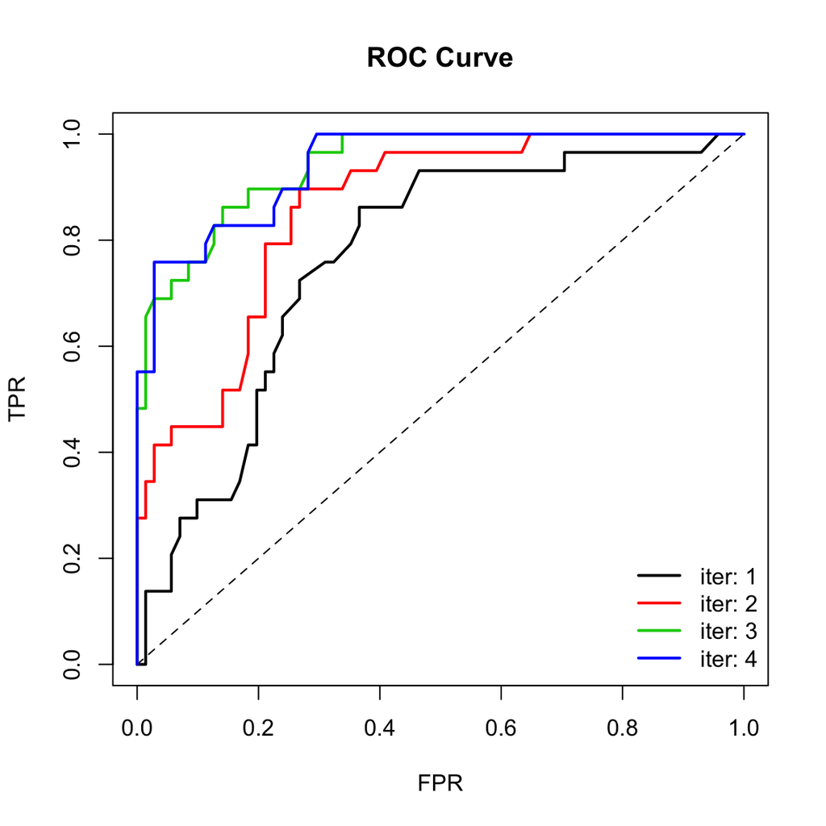

```r
legend('bottomright', legend=paste('iter:', 1:iter), col=1:iter, lwd=2, bty='n')
```

### Variable Importance

The outputs of `iRF::randomForest` are objects of class `randomForest` and can be used with other functions in the R package `randomForest` directly, e.g., to visualize variable importance measures:

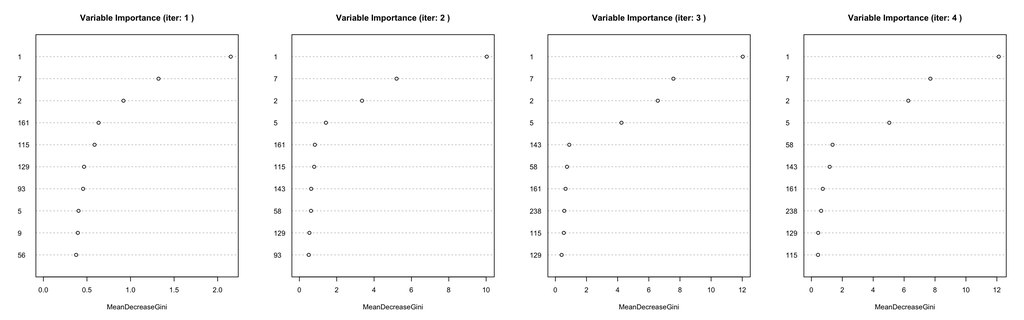

```r
par(mfrow=c(1,4))
for (iter in 1:4)
  varImpPlot(rf[[iter]], n.var=10, main=paste('Variable Importance (iter:', iter, ')'))
```

### Regression

For regression, the usage is similar:

```r
# change to a continuous response
b <- c(rep(1, 2), rep(0, p-2))
Y <- X %*% b + rnorm(n)

# iteratively grow RF, use Gini importance of features as weights
rf <- list()
sel.prob <- rep(1/p, p)
for (iter in 1:4){
  cat(paste('iter = ', iter, ':: '))
  rf[[iter]] <- randomForest(x=X[train.id,], y=Y[train.id],
                             xtest=X[test.id,], ytest=Y[test.id],
                             mtry.select.prob=sel.prob)

  # update selection probabilities for next iteration
  sel.prob <- rf[[iter]]$importance/sum(rf[[iter]]$importance)

  # performance on test set
  test.error = mean((rf[[iter]]$test$predicted - Y[test.id]) ^ 2) / var(Y[test.id])
  cat(paste('test error: ', round(100*test.error, 2), '%\n', sep=''))
}
```

```
## iter =  1 :: test error: 67.72%
## iter =  2 :: test error: 61.52%
## iter =  3 :: test error: 61.02%
## iter =  4 :: test error: 61.19%
```

### Parallel implementation

```r
# set up cores for parallel implementation
library(doMC)
registerDoMC()
n.cores <- 4
options(cores=n.cores)
n.tree.per.core <- 30

rfpar <- foreach(n.tree=rep(n.tree.per.core, n.cores),
                 .combine=combine, .multicombine=TRUE)%dopar%{
   randomForest(x=X[train.id,], y=Y[train.id], ntree=n.tree)
}
```

## B. Detect high-order feature interactions in a stable fashion

`iRF` detects high-order interaction among features by analyzing feature usage on the decision paths of large nodes in a random forest. In particular, given a (weighted) random forest fit, `iRF` (i) passes the training data through the fitted forest and records the features used on the associated decision paths; (ii) Applies a weighted version of the random intersection tree (RIT) algorithm proposed by [Shah and Meinshausen (2014)](http://jmlr.org/papers/v15/shah14a.html) to find high-order feature combinations prevalent in the decision paths, where weights are determined by user specified features; (iii) performs the above two steps on many bootstrap replicates of the training set to assess stability of the features and their interactions.

### Feature usage on decision paths of large leaf nodes

Consider a classification example as before:

```r
  # simulate data for classification
  n <- 600
  p <- 250
  X <- matrix(rnorm(n*p), nrow=n)

  Y <- (X[,1] > 0.35 & X[,2] > 0.35) | (X[,5] > 0.35 & X[,7] > 0.35)
  Y <- as.factor(as.numeric(Y > 0))

  train.id <- 1:(n/2)
  test.id <- setdiff(1:n, train.id)
```

Next, we iteratively grow weighted random forests as before, but save the forest components for further processing.

```r
sel.prob <- rep(1/p, p)

# iteratively grow RF, use Gini importance of features as weights
rf <- list()
for (iter in 1:4){
  rf[[iter]] <- randomForest(x=X[train.id,], y=Y[train.id],
                             xtest=X[test.id,], ytest=Y[test.id],
                             mtry.select.prob=sel.prob,
                             keep.forest=TRUE, track.nodes=TRUE)

  # update selection probabilities for next iteration
  sel.prob <- rf[[iter]]$importance / sum(rf[[iter]]$importance)
}
```

To read feature usage on nodes, use the function `readForest`. This function can be run in parallel with the argument `n.core`, provided `doMC` has been set up for parallel processing. This function will calculate the the decrease in purity of responses in each leaf node relative to the full data, provided `wt.pred.accuracy` is TRUE.

```r
y.numeric <- as.numeric(Y) - 1
rforest <- readForest(rfobj=rf[[3]], x=X[train.id,], y=y.numeric[train.id],
                      wt.pred.accuracy=TRUE)

head(rforest$tree.info, n=10)
```

```
##     prediction node.idx parent tree size.node dec.purity
##  1:          2        7      3    1        29  1.0000000
##  2:          2        9      4    1         1  1.0000000
##  3:          1       10      5    1         2  1.0000000
##  4:          2       11      5    1        12  0.0000000
##  5:          1       12      6    1        36  1.0000000
##  6:          2       14      8    1         2  0.0000000
##  7:          1       16     13    1        10  1.0000000
##  8:          2       17     13    1        10  1.0000000
##  9:          1       20     18    1       141  0.7225969
## 10:          2       23     19    1         6  1.0000000
```

```r
head(rforest$node.feature, n=10)
```

```
##  [1] TRUE TRUE TRUE TRUE TRUE TRUE TRUE TRUE TRUE TRUE
```

### Finding feature interactions using random intersection trees (RIT)

To find prevalent sets of features and their high-order combinations used to define these nodes, use the random intersection trees (RIT) function. The following with the following command runs RIT on all class 1 nodes, sampling each leaf node with probability proportional to the number of observations in each leaf node:

```r
class1.nodes <- rforest$tree.info$prediction - 1 == 1
wt <- rforest$tree.info$size.node[class1.nodes]
RIT(rforest$node.feature[class1.nodes,], weights=wt,
    depth=5, branch=2, n_trees=100)
```

```
##   Interaction Prevalence
## 1         1 7  0.5480769
## 2         5 7  0.4454545
## 3         1 2  0.4380165
## 4         1 5  0.4368932
## 5         2 5  0.3217391
## 6         2 7  0.3142857
```

### Selecting Stable interactions

The function `iRF` combines all the above steps and uses bootstrap aggregation to assess stability of the selected interactions. The final output contains a list of named numeric vectors containing the stability scores.

```r
ff <- iRF(x=X[train.id,],
         y=Y[train.id],
         xtest=X[test.id,],
         ytest=Y[test.id],
         n.iter=5,
         n.core=n.cores,
         interactions.return=5,
         n.bootstrap=10
        )
```

```
## [1] "iteration =  1"
## [1] "AUROC:  0.95"
## [1] "iteration =  2"
## [1] "AUROC:  1"
## [1] "iteration =  3"
## [1] "AUROC:  1"
## [1] "iteration =  4"
## [1] "AUROC:  1"
## [1] "iteration =  5"
## finding interactions ... [1] "AUROC:  1"
```

```r
ff$interaction
```

```
## [[1]]
## NULL
##
## [[2]]
## NULL
##
## [[3]]
## NULL
##
## [[4]]
## NULL
##
## [[5]]
##     1_2     5_7     2_5     2_7     1_7     1_5    1_44   2_174   2_5_7
##     1.0     1.0     0.8     0.7     0.6     0.5     0.1     0.1     0.1
## 2_7_174    2_94   5_174   5_186   7_174    7_94
##     0.1     0.1     0.1     0.1     0.1     0.1
```

The selected interactions can be visualized using simple R functions like `dotchart`:

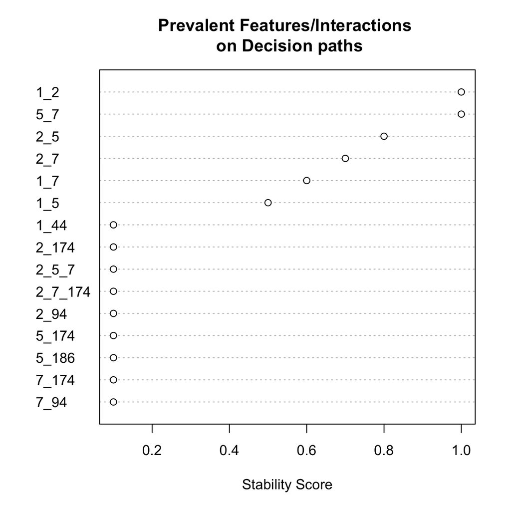

```r
toplot <- rev(ff$interaction[[5]])
dotchart(toplot[1:min(20, length(toplot))], xlab='Stability Score',
         main='Prevalent Features/Interactions \n on Decision paths')
```

### Visualizing partial dependence of two interacting features

The partial dependence function of two putatively interacting features can be calculated from data and visualized using the `partialPlot2var` function in the package. This feature uses the `persp3d()` function from the `rgl` package.

```r
library(knitr)
library(rgl)
knit_hooks$set(webgl = hook_webgl)
```

Here is an example of an interactive partial dependence plot:

```r
ff <- partialPlot2var(x1=X[,1], x2=X[,2], y=as.numeric(Y)-1, gridlength=6,
                      x1lab='X1', x2lab='X2', ylab='P(Y=1)', plot.colorbar=FALSE)
```

[interactive chart not shown]